# Task 1

f(x_1, x_2) = (x_1 + x_2)^2 = x_1^2 + 2x_1 x_2 + x_2^2;

x_1, x_2 ~ U[-1; 1];

x_1 = x_2

## ME

g(z) = E_{x_2 | x_1 = z}[z^2 + 2z x_2 + x_2^2] = z^2 + 2z^2 + z^2 = 4z^2

## ALE

int_{-1}^z {4v dv} = 2(z^2 - (-1)^2) =

2(z^2 - 1)

# Task 2

## Ceteris Paribus and Partial Dependence Plots for models trained to predict players' wages in the FIFA 23 game

We analyse the random forest model trained in previous assignments on the FIFA 23 game dataset. The model aims to predict players' wages given their statistics in the game.

We calculate Ceteris Paribus profiles for 5 chosen observations (Thomas Mueller, Henri Lansbury, Aketxe, Udoka Godwin-Malife and Guilherme Garutti) and four features - Overall, Potential, Age and Release Clause - and we analyse these profiles.

We find two observations with different Ceteris Paribus profiles for the Release Clause feature.

We compare the Ceteris Paribus profiles with Partial Dependence Plots (CP profiles averaged over the dataset).

We also compare Partial Dependence Plots for the random forest model with Partial Dependence Plots for the linear model trained in previous assignments.

### CP profiles

We calculate Ceteris Paribus profiles for 5 chosen observations - Thomas Mueller, Henri Lansbury, Aketxe, Udoka Godwin-Malife and Guilherme Garutti - and four features - Overall, Potential, Age and Release Clause.

We observe that the Overall feature has strong positive impact on predictions - the higher Overall, the higher prediction. Huge correlation between Overall and wage is rather an expected result. For the Potential feature we observe almost none impact on predictions. The Age feature also has small impact on predictions, but we observe some fluctuations for Thomas Mueller observation. The Release Clause feature seems to have some impact on predictions, although not as large as Overall. We observe positive correlation for Thomas Mueller observation. For the rest observations we observe increase of the prediction around zero value. This actually make sense, as a player with no release clause is expected to be better than a player with a very low release clause.

Ceteris Paribus profiles for the five chosen observations:

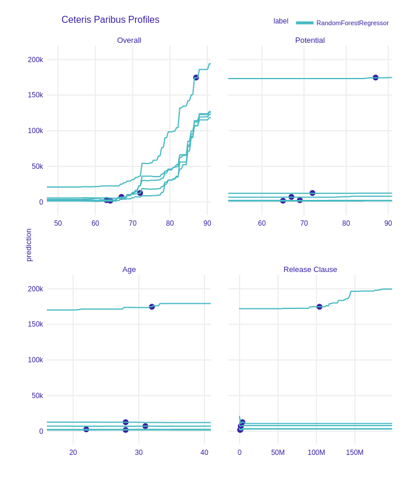

### Different CP profiles

We found two observations with different CP profiles for the Release Clause feature. Finding such an observation required checking around twenty observations and few different features. We observe increase-decrease-increase-stable progress of the prediction for the first observation and decrease-increase-stable progress for the second observation. It is also worth mentioning that for the first observation the true value was in a local maximum, while for the second observation it was in a local (and global) minimum. Progress similar to the second observation was observed really often, progresses as in the first observation were deviations.

CP profile for the first observation - Moleiro:

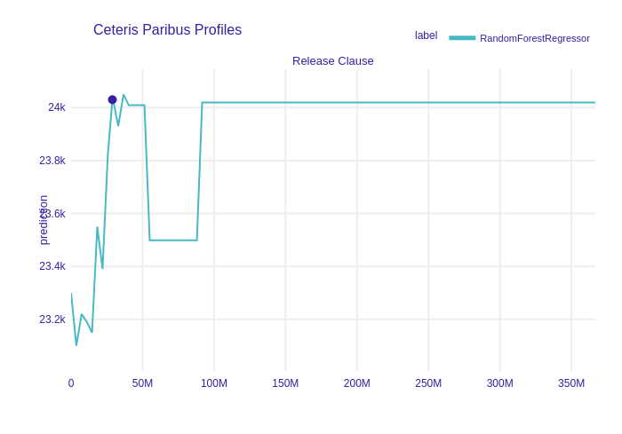

CP profile for the second observation - Richard van der Venne:

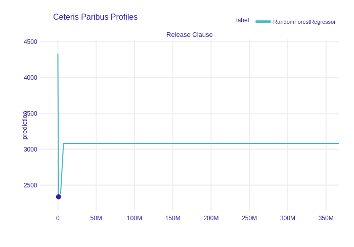

### PDP vs CP profiles

PD Plots and CP profiles for the four chosen features are quite similar. PD Plots are smoother that CP profiles, which should be expected as they are averaged which reduces sample variance. Important difference is observed for the Release Clause feature - in PDP we do not observe positive correlation (as for Thomas Mueller CP profile) and increase around zero value is much smaller than the one in CP profiles for the four remaining chosen observations.

CP profiles for the five chosen observations:

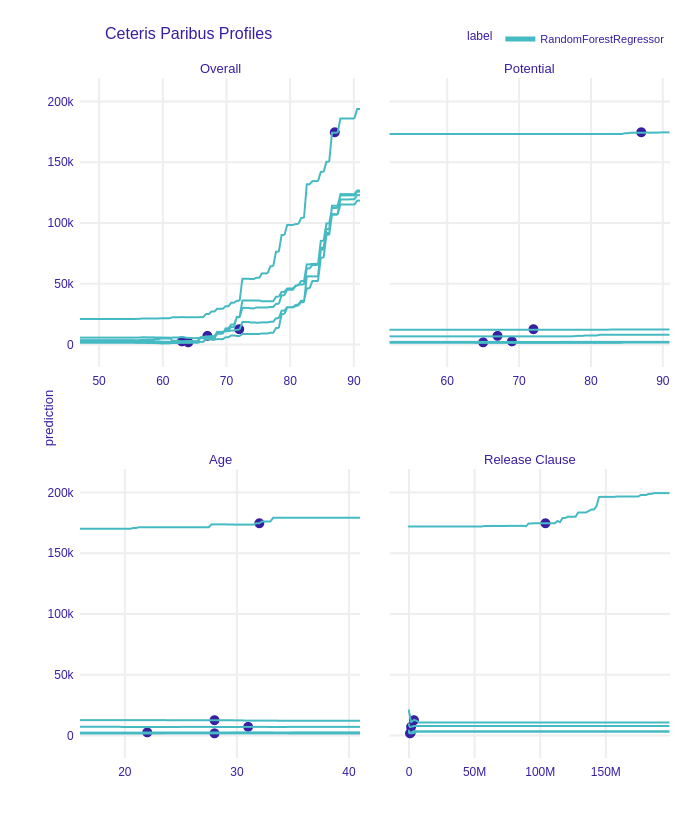

PDP for the tree model:

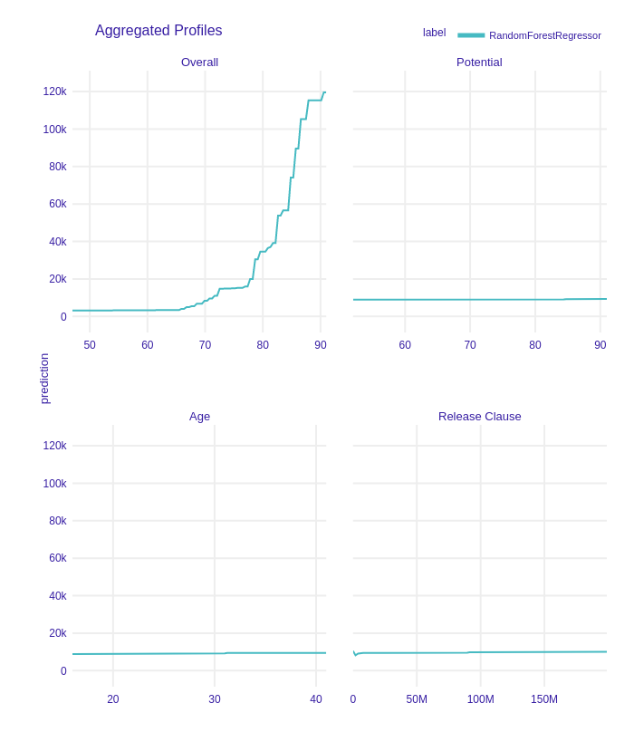

### PDP for the tree model vs PDP for the linear model

PD plots for the tree model and the linear model differ, although show several similar tendencies. First thing worth mentioning is that PDP for the linear model are always lines which is expected for any linear model. PDP for the tree model are more diversified in shape and less smooth. For both models we observe positive correlation for Overall and small for Potential and Age (although the linear model suggests some correlation, while the tree model suggest almost none). We observe huge difference in explaining the Release Clause feature. The linear model indicates negative correlation and the tree model suggest only small correlation around zero value. Such a phenomenon can be expained by limitations of linear models - since PDP for a linear model must be line, we cannot determine correlation only around zero - we must extrapolate it on the whole domain.

PDP for the tree model:

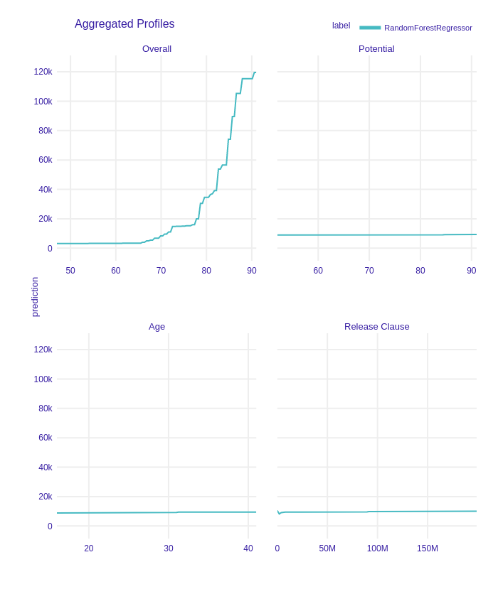

PDP for the linear model

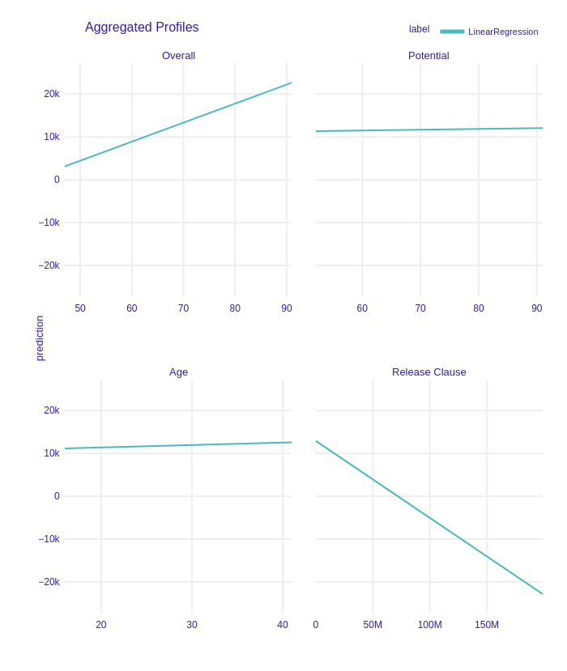

### Summary

The methods seem to work well for the tree models. For linear models the method is quite limited, as in results we obtain only lines.

Outcomes from the PDP method are smoother than the ones from the CP method, as averaging reduces variance.

Important correlations are present in both CP and PD profiles, although CP profiles contain some observation-specific tendencies.

## Appendix

### Importing libraries and dataset

```python
# 1. Import libraries

!pip3 install shap
!pip3 install dalex
!pip3 install lime
!pip3 install -q condacolab
import condacolab
condacolab.install()
!conda install -c conda-forge python-kaleido

import pandas as pd
import numpy as np
import matplotlib.pyplot as plt
import plotly
import kaleido

import pickle
import lime
import shap
import dalex as dx

from math import isclose

from sklearn.linear_model import LinearRegression
from sklearn.ensemble import RandomForestRegressor
```

[output not shown]

```python
# 2. Load dataset and models from the previous homework

with open('X_train.pickle', 'rb') as handle:
    X_train_load = pickle.load(handle)

with open('y_train.pickle', 'rb') as handle:
    y_train_load = pickle.load(handle)

with open('X_test.pickle', 'rb') as handle:
    X_test_load = pickle.load(handle)

with open('y_test.pickle', 'rb') as handle:
    y_test_load = pickle.load(handle)

with open('tree_model.pickle', 'rb') as handle:
    forest_reg_load = pickle.load(handle)

with open('linear_model.pickle', 'rb') as handle:
    linear_model_load = pickle.load(handle)

print(X_train_load)
print(y_train_load)
print(X_test_load)
print(y_train_load)
print(forest_reg_load.predict(X_train_load))
print(linear_model_load.predict(X_train_load))
print(forest_reg_load.predict(X_test_load))
print(linear_model_load.predict(X_test_load))
```

```
       Overall  Potential  Value(in Euro)  Age  Height(in cm)  Weight(in kg)  \
1127        76         77         9000000   27            190             85
6725        68         68         1200000   28            190             87
4966        70         70         1100000   31            190             93
1799        75         75         6000000   22            188             84
4484        70         70         1300000   32            165             63
...        ...        ...             ...  ...            ...            ...
11284       64         64          525000   28            183             83
11964       63         69          700000   23            176             70
5390        69         69          375000   35            187             85
860         77         77        10500000   29            176             73
15795       59         59          220000   29            170             70

       TotalStats  BaseStats  Release Clause  Weak Foot Rating  ...  \
1127         1808        392               0                 3  ...
```

[output cut: 173 more lines]

### Analysys of the model

```python
# 1. Observe predictions of 5 observations (POINT 1)

observations = X_test_load.sample(5, random_state = 1)

predictions_forest = forest_reg_load.predict(observations)

predictions_linear = linear_model_load.predict(observations)

print(observations)
print(predictions_forest)
print(predictions_linear)
```

```
       Overall  Potential  Value(in Euro)  Age  Height(in cm)  Weight(in kg)  \
34          87         87        63000000   32            185             76
8193        67         67          825000   31            183             85
3106        72         72         2400000   28            174             69
12140       63         69          700000   22            180             79
11521       64         65          550000   28            192             86

       TotalStats  BaseStats  Release Clause  Weak Foot Rating  ...  \
34           2140        443       104000000                 4  ...
8193         1880        384         1600000                 3  ...
3106         1917        390         3800000                 3  ...
12140        1593        351         1400000                 2  ...
11521        1515        327          784000                 2  ...

       Best_Position_RM  Best_Position_RW  Best_Position_RWB  \
34                    0                 0                  0
8193                  0                 0                  0
3106                  0                 0                  0
12140                 0                 0                  0
11521                 0                 0                  0

       Best_Position_ST  Attacking_Work_Rate_High  Attacking_Work_Rate_Low  \
34                    0                         1                        0
8193                  0                         0                        0
3106                  0                         0                        0
12140                 0                         1                        0
11521                 0                         0                        0

       Attacking_Work_Rate_Medium  Defensive_Work_Rate_High  \
34                              0                         1
8193                            1                         0
3106                            1                         0
12140                           0                         0
11521                           1                         0

       Defensive_Work_Rate_Low  Defensive_Work_Rate_Medium
34                           0                           0
8193                         0                           1
3106                         0                           1
12140                        0                           1
11521                        0                           1

[5 rows x 111 columns]
[174720.    7040.   12525.5   2482.5   1698.5]
[146171.12695566   9739.75500015   6601.38942177   5714.57255113
   2513.08255573]
```

```python
# 2. Calculate Ceteris Paribus profiles for selected observations with dalex library for the forest model (POINT 2)

explainer_forest_dx = dx.Explainer(forest_reg_load, X_test_load, y_test_load, verbose = False)

print(observations.columns)

cp_10 = explainer_forest_dx.predict_profile(new_observation=observations)
fig = cp_10.plot(variables = ["Overall", "Potential", "Age", "Release Clause"], show = False)
fig.write_image('Point2_im.png')
```

```
Index(['Overall', 'Potential', 'Value(in Euro)', 'Age', 'Height(in cm)',
       'Weight(in kg)', 'TotalStats', 'BaseStats', 'Release Clause',
       'Weak Foot Rating',
       ...
       'Best_Position_RM', 'Best_Position_RW', 'Best_Position_RWB',
       'Best_Position_ST', 'Attacking_Work_Rate_High',
       'Attacking_Work_Rate_Low', 'Attacking_Work_Rate_Medium',
       'Defensive_Work_Rate_High', 'Defensive_Work_Rate_Low',
       'Defensive_Work_Rate_Medium'],
      dtype='object', length=111)
```

```python
# 3. Search for observations with different Ceteris Paribus profiles (POINT 3)

search_set = X_test_load.sample(20, random_state = 3)
cp_10_search = explainer_forest_dx.predict_profile(new_observation=search_set)
```

```python
cp_10_search.plot(variables = ['Release Clause'])
```

[interactive chart not shown]

```python
for id in range(2):
    i = id + len(search_set)-2
    print(search_set.iloc[i])
    cp_10_search_i = explainer_forest_dx.predict_profile(new_observation=search_set.iloc[i])
    fig = cp_10_search_i.plot(variables=['Release Clause'], show = False)
    fig.write_image('Point3_im' + str(id + 1) + '.png')
```

```
Overall                             75
Potential                           90
Value(in Euro)                13000000
Age                                 18
Height(in cm)                      169
                                ...
Attacking_Work_Rate_Low              0
Attacking_Work_Rate_Medium           1
Defensive_Work_Rate_High             0
Defensive_Work_Rate_Low              0
Defensive_Work_Rate_Medium           1
Name: 1584, Length: 111, dtype: int64
Overall                           65
Potential                         65
Value(in Euro)                700000
Age                               30
Height(in cm)                    173
                               ...
Attacking_Work_Rate_Low            0
Attacking_Work_Rate_Medium         0
Defensive_Work_Rate_High           0
Defensive_Work_Rate_Low            0
Defensive_Work_Rate_Medium         1
Name: 9967, Length: 111, dtype: int64
```

```python
# 4. Calculate Partial Dependence Plots profiles for selected observations with dalex library for the forest model (POINT 4, 5)

pdp = explainer_forest_dx.model_profile(N = 30)
```

```python
fig = pdp.plot(variables=["Overall", "Potential", "Age", "Release Clause"], show = False)
fig.write_image('Point4_im.png')
```

```python
# 5. Calculate Partial Dependence Plots profiles for selected observations with dalex library for the linear model (POINT 5)

explainer_linear_dx = dx.Explainer(linear_model_load, X_test_load, y_test_load, verbose = False)
```

```python
pdp_linear = explainer_linear_dx.model_profile(N = 30)
```

```python
fig = pdp_linear.plot(variables=["Overall", "Potential", "Age", "Release Clause"], show = False)
fig.write_image('Point5_im.png')
```